# Project: Wrangling and Analyze Data

## Data Gathering

1. Directly download the WeRateDogs Twitter archive data (twitter_archive_enhanced.csv)

```python
import pandas as pd
import numpy as np

df1 = pd.read_csv('twitter-archive-enhanced.csv')
```

1. Use the Requests library to download the tweet image prediction (image_predictions.tsv)

```python
import requests

r = requests.get("https://d17h27t6h515a5.cloudfront.net/topher/2017/August/599fd2ad_image-predictions/image-predictions.tsv")
file = open("image_predictions.tsv", "wb")
file.write(r.content)
file.close()
```

```python
# reading the 'image_predictions.tsv' file

df2 = pd.read_csv('image_predictions.tsv', sep = '\t')
```

1. Use the Tweepy library to query additional data via the Twitter API (tweet_json.txt)

```python
import json

#query Twitter API for JSON data for each twitter id in the twitter archive
df_list = []
#reading the json file and reading through for loop, line by line
with open('tweet-json.txt', 'r') as file:
    for line in file:
        tweets = json.loads(line)
        tweet_id = tweets['id']
        retweet_count = tweets['retweet_count']
        favorite_count = tweets['favorite_count']
        df_list.append({'tweets': tweets,
                       'tweet_id': tweet_id,
                       'retweet_count': retweet_count,
                      'favorite_count': favorite_count})

df3 = pd.DataFrame(df_list)
```

## Assessing Data

#### Assessing the three data for Quality and Tidiness issues

**Visual Assessment**

```python
# Display the twitter_archive_enhanced table

df1
```

|  | tweet_id | in_reply_to_status_id | in_reply_to_user_id | timestamp | source | text | retweeted_status_id | retweeted_status_user_id | retweeted_status_timestamp | expanded_urls | rating_numerator | rating_denominator | name | doggo | floofer | pupper | puppo |
| --- | --- | --- | --- | --- | --- | --- | --- | --- | --- | --- | --- | --- | --- | --- | --- | --- | --- |
| 0 | 892420643555336193 | NaN | NaN | 2017-08-01 16:23:56 +0000 | <a href="http://twitter.com/download/iphone" r... | This is Phineas. He's a mystical boy. Only eve... | NaN | NaN | NaN | https://twitter.com/dog_rates/status/892420643... | 13 | 10 | Phineas | None | None | None | None |
| 1 | 892177421306343426 | NaN | NaN | 2017-08-01 00:17:27 +0000 | <a href="http://twitter.com/download/iphone" r... | This is Tilly. She's just checking pup on you.... | NaN | NaN | NaN | https://twitter.com/dog_rates/status/892177421... | 13 | 10 | Tilly | None | None | None | None |
| 2 | 891815181378084864 | NaN | NaN | 2017-07-31 00:18:03 +0000 | <a href="http://twitter.com/download/iphone" r... | This is Archie. He is a rare Norwegian Pouncin... | NaN | NaN | NaN | https://twitter.com/dog_rates/status/891815181... | 12 | 10 | Archie | None | None | None | None |
| 3 | 891689557279858688 | NaN | NaN | 2017-07-30 15:58:51 +0000 | <a href="http://twitter.com/download/iphone" r... | This is Darla. She commenced a snooze mid meal... | NaN | NaN | NaN | https://twitter.com/dog_rates/status/891689557... | 13 | 10 | Darla | None | None | None | None |
| 4 | 891327558926688256 | NaN | NaN | 2017-07-29 16:00:24 +0000 | <a href="http://twitter.com/download/iphone" r... | This is Franklin. He would like you to stop ca... | NaN | NaN | NaN | https://twitter.com/dog_rates/status/891327558... | 12 | 10 | Franklin | None | None | None | None |
| 5 | 891087950875897856 | NaN | NaN | 2017-07-29 00:08:17 +0000 | <a href="http://twitter.com/download/iphone" r... | Here we have a majestic great white breaching ... | NaN | NaN | NaN | https://twitter.com/dog_rates/status/891087950... | 13 | 10 | None | None | None | None | None |
| 6 | 890971913173991426 | NaN | NaN | 2017-07-28 16:27:12 +0000 | <a href="http://twitter.com/download/iphone" r... | Meet Jax. He enjoys ice cream so much he gets ... | NaN | NaN | NaN | https://gofundme.com/ydvmve-surgery-for-jax,ht... | 13 | 10 | Jax | None | None | None | None |
| 7 | 890729181411237888 | NaN | NaN | 2017-07-28 00:22:40 +0000 | <a href="http://twitter.com/download/iphone" r... | When you watch your owner call another dog a g... | NaN | NaN | NaN | https://twitter.com/dog_rates/status/890729181... | 13 | 10 | None | None | None | None | None |
| 8 | 890609185150312448 | NaN | NaN | 2017-07-27 16:25:51 +0000 | <a href="http://twitter.com/download/iphone" r... | This is Zoey. She doesn't want to be one of th... | NaN | NaN | NaN | https://twitter.com/dog_rates/status/890609185... | 13 | 10 | Zoey | None | None | None | None |
| 9 | 890240255349198849 | NaN | NaN | 2017-07-26 15:59:51 +0000 | <a href="http://twitter.com/download/iphone" r... | This is Cassie. She is a college pup. Studying... | NaN | NaN | NaN | https://twitter.com/dog_rates/status/890240255... | 14 | 10 | Cassie | doggo | None | None | None |
| 10 | 890006608113172480 | NaN | NaN | 2017-07-26 00:31:25 +0000 | <a href="http://twitter.com/download/iphone" r... | This is Koda. He is a South Australian decksha... | NaN | NaN | NaN | https://twitter.com/dog_rates/status/890006608... | 13 | 10 | Koda | None | None | None | None |
| 11 | 889880896479866881 | NaN | NaN | 2017-07-25 16:11:53 +0000 | <a href="http://twitter.com/download/iphone" r... | This is Bruno. He is a service shark. Only get... | NaN | NaN | NaN | https://twitter.com/dog_rates/status/889880896... | 13 | 10 | Bruno | None | None | None | None |
| 12 | 889665388333682689 | NaN | NaN | 2017-07-25 01:55:32 +0000 | <a href="http://twitter.com/download/iphone" r... | Here's a puppo that seems to be on the fence a... | NaN | NaN | NaN | https://twitter.com/dog_rates/status/889665388... | 13 | 10 | None | None | None | None | puppo |
| 13 | 889638837579907072 | NaN | NaN | 2017-07-25 00:10:02 +0000 | <a href="http://twitter.com/download/iphone" r... | This is Ted. He does his best. Sometimes that'... | NaN | NaN | NaN | https://twitter.com/dog_rates/status/889638837... | 12 | 10 | Ted | None | None | None | None |
| 14 | 889531135344209921 | NaN | NaN | 2017-07-24 17:02:04 +0000 | <a href="http://twitter.com/download/iphone" r... | This is Stuart. He's sporting his favorite fan... | NaN | NaN | NaN | https://twitter.com/dog_rates/status/889531135... | 13 | 10 | Stuart | None | None | None | puppo |
| 15 | 889278841981685760 | NaN | NaN | 2017-07-24 00:19:32 +0000 | <a href="http://twitter.com/download/iphone" r... | This is Oliver. You're witnessing one of his m... | NaN | NaN | NaN | https://twitter.com/dog_rates/status/889278841... | 13 | 10 | Oliver | None | None | None | None |
| 16 | 888917238123831296 | NaN | NaN | 2017-07-23 00:22:39 +0000 | <a href="http://twitter.com/download/iphone" r... | This is Jim. He found a fren. Taught him how t... | NaN | NaN | NaN | https://twitter.com/dog_rates/status/888917238... | 12 | 10 | Jim | None | None | None | None |
| 17 | 888804989199671297 | NaN | NaN | 2017-07-22 16:56:37 +0000 | <a href="http://twitter.com/download/iphone" r... | This is Zeke. He has a new stick. Very proud o... | NaN | NaN | NaN | https://twitter.com/dog_rates/status/888804989... | 13 | 10 | Zeke | None | None | None | None |
| 18 | 888554962724278272 | NaN | NaN | 2017-07-22 00:23:06 +0000 | <a href="http://twitter.com/download/iphone" r... | This is Ralphus. He's powering up. Attempting ... | NaN | NaN | NaN | https://twitter.com/dog_rates/status/888554962... | 13 | 10 | Ralphus | None | None | None | None |
| 19 | 888202515573088257 | NaN | NaN | 2017-07-21 01:02:36 +0000 | <a href="http://twitter.com/download/iphone" r... | RT @dog_rates: This is Canela. She attempted s... | 8.874740e+17 | 4.196984e+09 | 2017-07-19 00:47:34 +0000 | https://twitter.com/dog_rates/status/887473957... | 13 | 10 | Canela | None | None | None | None |
| 20 | 888078434458587136 | NaN | NaN | 2017-07-20 16:49:33 +0000 | <a href="http://twitter.com/download/iphone" r... | This is Gerald. He was just told he didn't get... | NaN | NaN | NaN | https://twitter.com/dog_rates/status/888078434... | 12 | 10 | Gerald | None | None | None | None |
| 21 | 887705289381826560 | NaN | NaN | 2017-07-19 16:06:48 +0000 | <a href="http://twitter.com/download/iphone" r... | This is Jeffrey. He has a monopoly on the pool... | NaN | NaN | NaN | https://twitter.com/dog_rates/status/887705289... | 13 | 10 | Jeffrey | None | None | None | None |
| 22 | 887517139158093824 | NaN | NaN | 2017-07-19 03:39:09 +0000 | <a href="http://twitter.com/download/iphone" r... | I've yet to rate a Venezuelan Hover Wiener. Th... | NaN | NaN | NaN | https://twitter.com/dog_rates/status/887517139... | 14 | 10 | such | None | None | None | None |
| 23 | 887473957103951883 | NaN | NaN | 2017-07-19 00:47:34 +0000 | <a href="http://twitter.com/download/iphone" r... | This is Canela. She attempted some fancy porch... | NaN | NaN | NaN | https://twitter.com/dog_rates/status/887473957... | 13 | 10 | Canela | None | None | None | None |
| 24 | 887343217045368832 | NaN | NaN | 2017-07-18 16:08:03 +0000 | <a href="http://twitter.com/download/iphone" r... | You may not have known you needed to see this ... | NaN | NaN | NaN | https://twitter.com/dog_rates/status/887343217... | 13 | 10 | None | None | None | None | None |
| 25 | 887101392804085760 | NaN | NaN | 2017-07-18 00:07:08 +0000 | <a href="http://twitter.com/download/iphone" r... | This... is a Jubilant Antarctic House Bear. We... | NaN | NaN | NaN | https://twitter.com/dog_rates/status/887101392... | 12 | 10 | None | None | None | None | None |
| 26 | 886983233522544640 | NaN | NaN | 2017-07-17 16:17:36 +0000 | <a href="http://twitter.com/download/iphone" r... | This is Maya. She's very shy. Rarely leaves he... | NaN | NaN | NaN | https://twitter.com/dog_rates/status/886983233... | 13 | 10 | Maya | None | None | None | None |
| 27 | 886736880519319552 | NaN | NaN | 2017-07-16 23:58:41 +0000 | <a href="http://twitter.com/download/iphone" r... | This is Mingus. He's a wonderful father to his... | NaN | NaN | NaN | https://www.gofundme.com/mingusneedsus,https:/... | 13 | 10 | Mingus | None | None | None | None |
| 28 | 886680336477933568 | NaN | NaN | 2017-07-16 20:14:00 +0000 | <a href="http://twitter.com/download/iphone" r... | This is Derek. He's late for a dog meeting. 13... | NaN | NaN | NaN | https://twitter.com/dog_rates/status/886680336... | 13 | 10 | Derek | None | None | None | None |
| 29 | 886366144734445568 | NaN | NaN | 2017-07-15 23:25:31 +0000 | <a href="http://twitter.com/download/iphone" r... | This is Roscoe. Another pupper fallen victim t... | NaN | NaN | NaN | https://twitter.com/dog_rates/status/886366144... | 12 | 10 | Roscoe | None | None | pupper | None |
| ... | ... | ... | ... | ... | ... | ... | ... | ... | ... | ... | ... | ... | ... | ... | ... | ... | ... |
| 2326 | 666411507551481857 | NaN | NaN | 2015-11-17 00:24:19 +0000 | <a href="http://twitter.com/download/iphone" r... | This is quite the dog. Gets really excited whe... | NaN | NaN | NaN | https://twitter.com/dog_rates/status/666411507... | 2 | 10 | quite | None | None | None | None |
| 2327 | 666407126856765440 | NaN | NaN | 2015-11-17 00:06:54 +0000 | <a href="http://twitter.com/download/iphone" r... | This is a southern Vesuvius bumblegruff. Can d... | NaN | NaN | NaN | https://twitter.com/dog_rates/status/666407126... | 7 | 10 | a | None | None | None | None |
| 2328 | 666396247373291520 | NaN | NaN | 2015-11-16 23:23:41 +0000 | <a href="http://twitter.com/download/iphone" r... | Oh goodness. A super rare northeast Qdoba kang... | NaN | NaN | NaN | https://twitter.com/dog_rates/status/666396247... | 9 | 10 | None | None | None | None | None |
| 2329 | 666373753744588802 | NaN | NaN | 2015-11-16 21:54:18 +0000 | <a href="http://twitter.com/download/iphone" r... | Those are sunglasses and a jean jacket. 11/10 ... | NaN | NaN | NaN | https://twitter.com/dog_rates/status/666373753... | 11 | 10 | None | None | None | None | None |
| 2330 | 666362758909284353 | NaN | NaN | 2015-11-16 21:10:36 +0000 | <a href="http://twitter.com/download/iphone" r... | Unique dog here. Very small. Lives in containe... | NaN | NaN | NaN | https://twitter.com/dog_rates/status/666362758... | 6 | 10 | None | None | None | None | None |
| 2331 | 666353288456101888 | NaN | NaN | 2015-11-16 20:32:58 +0000 | <a href="http://twitter.com/download/iphone" r... | Here we have a mixed Asiago from the Galápagos... | NaN | NaN | NaN | https://twitter.com/dog_rates/status/666353288... | 8 | 10 | None | None | None | None | None |
| 2332 | 666345417576210432 | NaN | NaN | 2015-11-16 20:01:42 +0000 | <a href="http://twitter.com/download/iphone" r... | Look at this jokester thinking seat belt laws ... | NaN | NaN | NaN | https://twitter.com/dog_rates/status/666345417... | 10 | 10 | None | None | None | None | None |
| 2333 | 666337882303524864 | NaN | NaN | 2015-11-16 19:31:45 +0000 | <a href="http://twitter.com/download/iphone" r... | This is an extremely rare horned Parthenon. No... | NaN | NaN | NaN | https://twitter.com/dog_rates/status/666337882... | 9 | 10 | an | None | None | None | None |
| 2334 | 666293911632134144 | NaN | NaN | 2015-11-16 16:37:02 +0000 | <a href="http://twitter.com/download/iphone" r... | This is a funny dog. Weird toes. Won't come do... | NaN | NaN | NaN | https://twitter.com/dog_rates/status/666293911... | 3 | 10 | a | None | None | None | None |
| 2335 | 666287406224695296 | NaN | NaN | 2015-11-16 16:11:11 +0000 | <a href="http://twitter.com/download/iphone" r... | This is an Albanian 3 1/2 legged Episcopalian... | NaN | NaN | NaN | https://twitter.com/dog_rates/status/666287406... | 1 | 2 | an | None | None | None | None |
| 2336 | 666273097616637952 | NaN | NaN | 2015-11-16 15:14:19 +0000 | <a href="http://twitter.com/download/iphone" r... | Can take selfies 11/10 https://t.co/ws2AMaNwPW | NaN | NaN | NaN | https://twitter.com/dog_rates/status/666273097... | 11 | 10 | None | None | None | None | None |
| 2337 | 666268910803644416 | NaN | NaN | 2015-11-16 14:57:41 +0000 | <a href="http://twitter.com/download/iphone" r... | Very concerned about fellow dog trapped in com... | NaN | NaN | NaN | https://twitter.com/dog_rates/status/666268910... | 10 | 10 | None | None | None | None | None |
| 2338 | 666104133288665088 | NaN | NaN | 2015-11-16 04:02:55 +0000 | <a href="http://twitter.com/download/iphone" r... | Not familiar with this breed. No tail (weird).... | NaN | NaN | NaN | https://twitter.com/dog_rates/status/666104133... | 1 | 10 | None | None | None | None | None |
| 2339 | 666102155909144576 | NaN | NaN | 2015-11-16 03:55:04 +0000 | <a href="http://twitter.com/download/iphone" r... | Oh my. Here you are seeing an Adobe Setter giv... | NaN | NaN | NaN | https://twitter.com/dog_rates/status/666102155... | 11 | 10 | None | None | None | None | None |
| 2340 | 666099513787052032 | NaN | NaN | 2015-11-16 03:44:34 +0000 | <a href="http://twitter.com/download/iphone" r... | Can stand on stump for what seems like a while... | NaN | NaN | NaN | https://twitter.com/dog_rates/status/666099513... | 8 | 10 | None | None | None | None | None |
| 2341 | 666094000022159362 | NaN | NaN | 2015-11-16 03:22:39 +0000 | <a href="http://twitter.com/download/iphone" r... | This appears to be a Mongolian Presbyterian mi... | NaN | NaN | NaN | https://twitter.com/dog_rates/status/666094000... | 9 | 10 | None | None | None | None | None |
| 2342 | 666082916733198337 | NaN | NaN | 2015-11-16 02:38:37 +0000 | <a href="http://twitter.com/download/iphone" r... | Here we have a well-established sunblockerspan... | NaN | NaN | NaN | https://twitter.com/dog_rates/status/666082916... | 6 | 10 | None | None | None | None | None |
| 2343 | 666073100786774016 | NaN | NaN | 2015-11-16 01:59:36 +0000 | <a href="http://twitter.com/download/iphone" r... | Let's hope this flight isn't Malaysian (lol). ... | NaN | NaN | NaN | https://twitter.com/dog_rates/status/666073100... | 10 | 10 | None | None | None | None | None |
| 2344 | 666071193221509120 | NaN | NaN | 2015-11-16 01:52:02 +0000 | <a href="http://twitter.com/download/iphone" r... | Here we have a northern speckled Rhododendron.... | NaN | NaN | NaN | https://twitter.com/dog_rates/status/666071193... | 9 | 10 | None | None | None | None | None |
| 2345 | 666063827256086533 | NaN | NaN | 2015-11-16 01:22:45 +0000 | <a href="http://twitter.com/download/iphone" r... | This is the happiest dog you will ever see. Ve... | NaN | NaN | NaN | https://twitter.com/dog_rates/status/666063827... | 10 | 10 | the | None | None | None | None |
| 2346 | 666058600524156928 | NaN | NaN | 2015-11-16 01:01:59 +0000 | <a href="http://twitter.com/download/iphone" r... | Here is the Rand Paul of retrievers folks! He'... | NaN | NaN | NaN | https://twitter.com/dog_rates/status/666058600... | 8 | 10 | the | None | None | None | None |
| 2347 | 666057090499244032 | NaN | NaN | 2015-11-16 00:55:59 +0000 | <a href="http://twitter.com/download/iphone" r... | My oh my. This is a rare blond Canadian terrie... | NaN | NaN | NaN | https://twitter.com/dog_rates/status/666057090... | 9 | 10 | a | None | None | None | None |
| 2348 | 666055525042405380 | NaN | NaN | 2015-11-16 00:49:46 +0000 | <a href="http://twitter.com/download/iphone" r... | Here is a Siberian heavily armored polar bear ... | NaN | NaN | NaN | https://twitter.com/dog_rates/status/666055525... | 10 | 10 | a | None | None | None | None |
| 2349 | 666051853826850816 | NaN | NaN | 2015-11-16 00:35:11 +0000 | <a href="http://twitter.com/download/iphone" r... | This is an odd dog. Hard on the outside but lo... | NaN | NaN | NaN | https://twitter.com/dog_rates/status/666051853... | 2 | 10 | an | None | None | None | None |
| 2350 | 666050758794694657 | NaN | NaN | 2015-11-16 00:30:50 +0000 | <a href="http://twitter.com/download/iphone" r... | This is a truly beautiful English Wilson Staff... | NaN | NaN | NaN | https://twitter.com/dog_rates/status/666050758... | 10 | 10 | a | None | None | None | None |
| 2351 | 666049248165822465 | NaN | NaN | 2015-11-16 00:24:50 +0000 | <a href="http://twitter.com/download/iphone" r... | Here we have a 1949 1st generation vulpix. Enj... | NaN | NaN | NaN | https://twitter.com/dog_rates/status/666049248... | 5 | 10 | None | None | None | None | None |
| 2352 | 666044226329800704 | NaN | NaN | 2015-11-16 00:04:52 +0000 | <a href="http://twitter.com/download/iphone" r... | This is a purebred Piers Morgan. Loves to Netf... | NaN | NaN | NaN | https://twitter.com/dog_rates/status/666044226... | 6 | 10 | a | None | None | None | None |
| 2353 | 666033412701032449 | NaN | NaN | 2015-11-15 23:21:54 +0000 | <a href="http://twitter.com/download/iphone" r... | Here is a very happy pup. Big fan of well-main... | NaN | NaN | NaN | https://twitter.com/dog_rates/status/666033412... | 9 | 10 | a | None | None | None | None |
| 2354 | 666029285002620928 | NaN | NaN | 2015-11-15 23:05:30 +0000 | <a href="http://twitter.com/download/iphone" r... | This is a western brown Mitsubishi terrier. Up... | NaN | NaN | NaN | https://twitter.com/dog_rates/status/666029285... | 7 | 10 | a | None | None | None | None |
| 2355 | 666020888022790149 | NaN | NaN | 2015-11-15 22:32:08 +0000 | <a href="http://twitter.com/download/iphone" r... | Here we have a Japanese Irish Setter. Lost eye... | NaN | NaN | NaN | https://twitter.com/dog_rates/status/666020888... | 8 | 10 | None | None | None | None | None |

2356 rows × 17 columns

- Missing entries in ('in_reply_to_status_id', 'in_reply_to_user_id', 'retweeted_status_id', 'retweeted_status_user_id' and 'retweeted_status_timestamp')
- unexpected articles('a', 'an', 'the') in the 'name' column
- Nulls represented as 'None' in ('name', 'doggo', 'floofer', 'pupper', 'puppo') columns

```python
#Display the 'image_predictions' table

df2
```

|  | tweet_id | jpg_url | img_num | p1 | p1_conf | p1_dog | p2 | p2_conf | p2_dog | p3 | p3_conf | p3_dog |
| --- | --- | --- | --- | --- | --- | --- | --- | --- | --- | --- | --- | --- |
| 0 | 666020888022790149 | https://pbs.twimg.com/media/CT4udn0WwAA0aMy.jpg | 1 | Welsh_springer_spaniel | 0.465074 | True | collie | 0.156665 | True | Shetland_sheepdog | 0.061428 | True |
| 1 | 666029285002620928 | https://pbs.twimg.com/media/CT42GRgUYAA5iDo.jpg | 1 | redbone | 0.506826 | True | miniature_pinscher | 0.074192 | True | Rhodesian_ridgeback | 0.072010 | True |
| 2 | 666033412701032449 | https://pbs.twimg.com/media/CT4521TWwAEvMyu.jpg | 1 | German_shepherd | 0.596461 | True | malinois | 0.138584 | True | bloodhound | 0.116197 | True |
| 3 | 666044226329800704 | https://pbs.twimg.com/media/CT5Dr8HUEAA-lEu.jpg | 1 | Rhodesian_ridgeback | 0.408143 | True | redbone | 0.360687 | True | miniature_pinscher | 0.222752 | True |
| 4 | 666049248165822465 | https://pbs.twimg.com/media/CT5IQmsXIAAKY4A.jpg | 1 | miniature_pinscher | 0.560311 | True | Rottweiler | 0.243682 | True | Doberman | 0.154629 | True |
| 5 | 666050758794694657 | https://pbs.twimg.com/media/CT5Jof1WUAEuVxN.jpg | 1 | Bernese_mountain_dog | 0.651137 | True | English_springer | 0.263788 | True | Greater_Swiss_Mountain_dog | 0.016199 | True |
| 6 | 666051853826850816 | https://pbs.twimg.com/media/CT5KoJ1WoAAJash.jpg | 1 | box_turtle | 0.933012 | False | mud_turtle | 0.045885 | False | terrapin | 0.017885 | False |
| 7 | 666055525042405380 | https://pbs.twimg.com/media/CT5N9tpXIAAifs1.jpg | 1 | chow | 0.692517 | True | Tibetan_mastiff | 0.058279 | True | fur_coat | 0.054449 | False |
| 8 | 666057090499244032 | https://pbs.twimg.com/media/CT5PY90WoAAQGLo.jpg | 1 | shopping_cart | 0.962465 | False | shopping_basket | 0.014594 | False | golden_retriever | 0.007959 | True |
| 9 | 666058600524156928 | https://pbs.twimg.com/media/CT5Qw94XAAA_2dP.jpg | 1 | miniature_poodle | 0.201493 | True | komondor | 0.192305 | True | soft-coated_wheaten_terrier | 0.082086 | True |
| 10 | 666063827256086533 | https://pbs.twimg.com/media/CT5Vg_wXIAAXfnj.jpg | 1 | golden_retriever | 0.775930 | True | Tibetan_mastiff | 0.093718 | True | Labrador_retriever | 0.072427 | True |
| 11 | 666071193221509120 | https://pbs.twimg.com/media/CT5cN_3WEAAlOoZ.jpg | 1 | Gordon_setter | 0.503672 | True | Yorkshire_terrier | 0.174201 | True | Pekinese | 0.109454 | True |
| 12 | 666073100786774016 | https://pbs.twimg.com/media/CT5d9DZXAAALcwe.jpg | 1 | Walker_hound | 0.260857 | True | English_foxhound | 0.175382 | True | Ibizan_hound | 0.097471 | True |
| 13 | 666082916733198337 | https://pbs.twimg.com/media/CT5m4VGWEAAtKc8.jpg | 1 | pug | 0.489814 | True | bull_mastiff | 0.404722 | True | French_bulldog | 0.048960 | True |
| 14 | 666094000022159362 | https://pbs.twimg.com/media/CT5w9gUW4AAsBNN.jpg | 1 | bloodhound | 0.195217 | True | German_shepherd | 0.078260 | True | malinois | 0.075628 | True |
| 15 | 666099513787052032 | https://pbs.twimg.com/media/CT51-JJUEAA6hV8.jpg | 1 | Lhasa | 0.582330 | True | Shih-Tzu | 0.166192 | True | Dandie_Dinmont | 0.089688 | True |
| 16 | 666102155909144576 | https://pbs.twimg.com/media/CT54YGiWUAEZnoK.jpg | 1 | English_setter | 0.298617 | True | Newfoundland | 0.149842 | True | borzoi | 0.133649 | True |
| 17 | 666104133288665088 | https://pbs.twimg.com/media/CT56LSZWoAAlJj2.jpg | 1 | hen | 0.965932 | False | cock | 0.033919 | False | partridge | 0.000052 | False |
| 18 | 666268910803644416 | https://pbs.twimg.com/media/CT8QCd1WEAADXws.jpg | 1 | desktop_computer | 0.086502 | False | desk | 0.085547 | False | bookcase | 0.079480 | False |
| 19 | 666273097616637952 | https://pbs.twimg.com/media/CT8T1mtUwAA3aqm.jpg | 1 | Italian_greyhound | 0.176053 | True | toy_terrier | 0.111884 | True | basenji | 0.111152 | True |
| 20 | 666287406224695296 | https://pbs.twimg.com/media/CT8g3BpUEAAuFjg.jpg | 1 | Maltese_dog | 0.857531 | True | toy_poodle | 0.063064 | True | miniature_poodle | 0.025581 | True |
| 21 | 666293911632134144 | https://pbs.twimg.com/media/CT8mx7KW4AEQu8N.jpg | 1 | three-toed_sloth | 0.914671 | False | otter | 0.015250 | False | great_grey_owl | 0.013207 | False |
| 22 | 666337882303524864 | https://pbs.twimg.com/media/CT9OwFIWEAMuRje.jpg | 1 | ox | 0.416669 | False | Newfoundland | 0.278407 | True | groenendael | 0.102643 | True |
| 23 | 666345417576210432 | https://pbs.twimg.com/media/CT9Vn7PWoAA_ZCM.jpg | 1 | golden_retriever | 0.858744 | True | Chesapeake_Bay_retriever | 0.054787 | True | Labrador_retriever | 0.014241 | True |
| 24 | 666353288456101888 | https://pbs.twimg.com/media/CT9cx0tUEAAhNN_.jpg | 1 | malamute | 0.336874 | True | Siberian_husky | 0.147655 | True | Eskimo_dog | 0.093412 | True |
| 25 | 666362758909284353 | https://pbs.twimg.com/media/CT9lXGsUcAAyUFt.jpg | 1 | guinea_pig | 0.996496 | False | skunk | 0.002402 | False | hamster | 0.000461 | False |
| 26 | 666373753744588802 | https://pbs.twimg.com/media/CT9vZEYWUAAlZ05.jpg | 1 | soft-coated_wheaten_terrier | 0.326467 | True | Afghan_hound | 0.259551 | True | briard | 0.206803 | True |
| 27 | 666396247373291520 | https://pbs.twimg.com/media/CT-D2ZHWIAA3gK1.jpg | 1 | Chihuahua | 0.978108 | True | toy_terrier | 0.009397 | True | papillon | 0.004577 | True |
| 28 | 666407126856765440 | https://pbs.twimg.com/media/CT-NvwmW4AAugGZ.jpg | 1 | black-and-tan_coonhound | 0.529139 | True | bloodhound | 0.244220 | True | flat-coated_retriever | 0.173810 | True |
| 29 | 666411507551481857 | https://pbs.twimg.com/media/CT-RugiWIAELEaq.jpg | 1 | coho | 0.404640 | False | barracouta | 0.271485 | False | gar | 0.189945 | False |
| ... | ... | ... | ... | ... | ... | ... | ... | ... | ... | ... | ... | ... |
| 2045 | 886366144734445568 | https://pbs.twimg.com/media/DE0BTnQUwAApKEH.jpg | 1 | French_bulldog | 0.999201 | True | Chihuahua | 0.000361 | True | Boston_bull | 0.000076 | True |
| 2046 | 886680336477933568 | https://pbs.twimg.com/media/DE4fEDzWAAAyHMM.jpg | 1 | convertible | 0.738995 | False | sports_car | 0.139952 | False | car_wheel | 0.044173 | False |
| 2047 | 886736880519319552 | https://pbs.twimg.com/media/DE5Se8FXcAAJFx4.jpg | 1 | kuvasz | 0.309706 | True | Great_Pyrenees | 0.186136 | True | Dandie_Dinmont | 0.086346 | True |
| 2048 | 886983233522544640 | https://pbs.twimg.com/media/DE8yicJW0AAAvBJ.jpg | 2 | Chihuahua | 0.793469 | True | toy_terrier | 0.143528 | True | can_opener | 0.032253 | False |
| 2049 | 887101392804085760 | https://pbs.twimg.com/media/DE-eAq6UwAA-jaE.jpg | 1 | Samoyed | 0.733942 | True | Eskimo_dog | 0.035029 | True | Staffordshire_bullterrier | 0.029705 | True |
| 2050 | 887343217045368832 | https://pbs.twimg.com/ext_tw_video_thumb/88734... | 1 | Mexican_hairless | 0.330741 | True | sea_lion | 0.275645 | False | Weimaraner | 0.134203 | True |
| 2051 | 887473957103951883 | https://pbs.twimg.com/media/DFDw2tyUQAAAFke.jpg | 2 | Pembroke | 0.809197 | True | Rhodesian_ridgeback | 0.054950 | True | beagle | 0.038915 | True |
| 2052 | 887517139158093824 | https://pbs.twimg.com/ext_tw_video_thumb/88751... | 1 | limousine | 0.130432 | False | tow_truck | 0.029175 | False | shopping_cart | 0.026321 | False |
| 2053 | 887705289381826560 | https://pbs.twimg.com/media/DFHDQBbXgAEqY7t.jpg | 1 | basset | 0.821664 | True | redbone | 0.087582 | True | Weimaraner | 0.026236 | True |
| 2054 | 888078434458587136 | https://pbs.twimg.com/media/DFMWn56WsAAkA7B.jpg | 1 | French_bulldog | 0.995026 | True | pug | 0.000932 | True | bull_mastiff | 0.000903 | True |
| 2055 | 888202515573088257 | https://pbs.twimg.com/media/DFDw2tyUQAAAFke.jpg | 2 | Pembroke | 0.809197 | True | Rhodesian_ridgeback | 0.054950 | True | beagle | 0.038915 | True |
| 2056 | 888554962724278272 | https://pbs.twimg.com/media/DFTH_O-UQAACu20.jpg | 3 | Siberian_husky | 0.700377 | True | Eskimo_dog | 0.166511 | True | malamute | 0.111411 | True |
| 2057 | 888804989199671297 | https://pbs.twimg.com/media/DFWra-3VYAA2piG.jpg | 1 | golden_retriever | 0.469760 | True | Labrador_retriever | 0.184172 | True | English_setter | 0.073482 | True |
| 2058 | 888917238123831296 | https://pbs.twimg.com/media/DFYRgsOUQAARGhO.jpg | 1 | golden_retriever | 0.714719 | True | Tibetan_mastiff | 0.120184 | True | Labrador_retriever | 0.105506 | True |
| 2059 | 889278841981685760 | https://pbs.twimg.com/ext_tw_video_thumb/88927... | 1 | whippet | 0.626152 | True | borzoi | 0.194742 | True | Saluki | 0.027351 | True |
| 2060 | 889531135344209921 | https://pbs.twimg.com/media/DFg_2PVW0AEHN3p.jpg | 1 | golden_retriever | 0.953442 | True | Labrador_retriever | 0.013834 | True | redbone | 0.007958 | True |
| 2061 | 889638837579907072 | https://pbs.twimg.com/media/DFihzFfXsAYGDPR.jpg | 1 | French_bulldog | 0.991650 | True | boxer | 0.002129 | True | Staffordshire_bullterrier | 0.001498 | True |
| 2062 | 889665388333682689 | https://pbs.twimg.com/media/DFi579UWsAAatzw.jpg | 1 | Pembroke | 0.966327 | True | Cardigan | 0.027356 | True | basenji | 0.004633 | True |
| 2063 | 889880896479866881 | https://pbs.twimg.com/media/DFl99B1WsAITKsg.jpg | 1 | French_bulldog | 0.377417 | True | Labrador_retriever | 0.151317 | True | muzzle | 0.082981 | False |
| 2064 | 890006608113172480 | https://pbs.twimg.com/media/DFnwSY4WAAAMliS.jpg | 1 | Samoyed | 0.957979 | True | Pomeranian | 0.013884 | True | chow | 0.008167 | True |
| 2065 | 890240255349198849 | https://pbs.twimg.com/media/DFrEyVuW0AAO3t9.jpg | 1 | Pembroke | 0.511319 | True | Cardigan | 0.451038 | True | Chihuahua | 0.029248 | True |
| 2066 | 890609185150312448 | https://pbs.twimg.com/media/DFwUU__XcAEpyXI.jpg | 1 | Irish_terrier | 0.487574 | True | Irish_setter | 0.193054 | True | Chesapeake_Bay_retriever | 0.118184 | True |
| 2067 | 890729181411237888 | https://pbs.twimg.com/media/DFyBahAVwAAhUTd.jpg | 2 | Pomeranian | 0.566142 | True | Eskimo_dog | 0.178406 | True | Pembroke | 0.076507 | True |
| 2068 | 890971913173991426 | https://pbs.twimg.com/media/DF1eOmZXUAALUcq.jpg | 1 | Appenzeller | 0.341703 | True | Border_collie | 0.199287 | True | ice_lolly | 0.193548 | False |
| 2069 | 891087950875897856 | https://pbs.twimg.com/media/DF3HwyEWsAABqE6.jpg | 1 | Chesapeake_Bay_retriever | 0.425595 | True | Irish_terrier | 0.116317 | True | Indian_elephant | 0.076902 | False |
| 2070 | 891327558926688256 | https://pbs.twimg.com/media/DF6hr6BUMAAzZgT.jpg | 2 | basset | 0.555712 | True | English_springer | 0.225770 | True | German_short-haired_pointer | 0.175219 | True |
| 2071 | 891689557279858688 | https://pbs.twimg.com/media/DF_q7IAWsAEuuN8.jpg | 1 | paper_towel | 0.170278 | False | Labrador_retriever | 0.168086 | True | spatula | 0.040836 | False |
| 2072 | 891815181378084864 | https://pbs.twimg.com/media/DGBdLU1WsAANxJ9.jpg | 1 | Chihuahua | 0.716012 | True | malamute | 0.078253 | True | kelpie | 0.031379 | True |
| 2073 | 892177421306343426 | https://pbs.twimg.com/media/DGGmoV4XsAAUL6n.jpg | 1 | Chihuahua | 0.323581 | True | Pekinese | 0.090647 | True | papillon | 0.068957 | True |
| 2074 | 892420643555336193 | https://pbs.twimg.com/media/DGKD1-bXoAAIAUK.jpg | 1 | orange | 0.097049 | False | bagel | 0.085851 | False | banana | 0.076110 | False |

2075 rows × 12 columns

- spaces represented as '_' in (p1, p2, p3) columns

```python
#Display the 'tweet_json' table

df3
```

|  | favorite_count | retweet_count | tweet_id | tweets |
| --- | --- | --- | --- | --- |
| 0 | 39467 | 8853 | 892420643555336193 | {'created_at': 'Tue Aug 01 16:23:56 +0000 2017... |
| 1 | 33819 | 6514 | 892177421306343426 | {'created_at': 'Tue Aug 01 00:17:27 +0000 2017... |
| 2 | 25461 | 4328 | 891815181378084864 | {'created_at': 'Mon Jul 31 00:18:03 +0000 2017... |
| 3 | 42908 | 8964 | 891689557279858688 | {'created_at': 'Sun Jul 30 15:58:51 +0000 2017... |
| 4 | 41048 | 9774 | 891327558926688256 | {'created_at': 'Sat Jul 29 16:00:24 +0000 2017... |
| 5 | 20562 | 3261 | 891087950875897856 | {'created_at': 'Sat Jul 29 00:08:17 +0000 2017... |
| 6 | 12041 | 2158 | 890971913173991426 | {'created_at': 'Fri Jul 28 16:27:12 +0000 2017... |
| 7 | 56848 | 16716 | 890729181411237888 | {'created_at': 'Fri Jul 28 00:22:40 +0000 2017... |
| 8 | 28226 | 4429 | 890609185150312448 | {'created_at': 'Thu Jul 27 16:25:51 +0000 2017... |
| 9 | 32467 | 7711 | 890240255349198849 | {'created_at': 'Wed Jul 26 15:59:51 +0000 2017... |
| 10 | 31166 | 7624 | 890006608113172480 | {'created_at': 'Wed Jul 26 00:31:25 +0000 2017... |
| 11 | 28268 | 5156 | 889880896479866881 | {'created_at': 'Tue Jul 25 16:11:53 +0000 2017... |
| 12 | 38818 | 8538 | 889665388333682689 | {'created_at': 'Tue Jul 25 01:55:32 +0000 2017... |
| 13 | 27672 | 4735 | 889638837579907072 | {'created_at': 'Tue Jul 25 00:10:02 +0000 2017... |
| 14 | 15359 | 2321 | 889531135344209921 | {'created_at': 'Mon Jul 24 17:02:04 +0000 2017... |
| 15 | 25652 | 5637 | 889278841981685760 | {'created_at': 'Mon Jul 24 00:19:32 +0000 2017... |
| 16 | 29611 | 4709 | 888917238123831296 | {'created_at': 'Sun Jul 23 00:22:39 +0000 2017... |
| 17 | 26080 | 4559 | 888804989199671297 | {'created_at': 'Sat Jul 22 16:56:37 +0000 2017... |
| 18 | 20290 | 3732 | 888554962724278272 | {'created_at': 'Sat Jul 22 00:23:06 +0000 2017... |
| 19 | 22201 | 3653 | 888078434458587136 | {'created_at': 'Thu Jul 20 16:49:33 +0000 2017... |
| 20 | 30779 | 5609 | 887705289381826560 | {'created_at': 'Wed Jul 19 16:06:48 +0000 2017... |
| 21 | 46959 | 12082 | 887517139158093824 | {'created_at': 'Wed Jul 19 03:39:09 +0000 2017... |
| 22 | 69871 | 18781 | 887473957103951883 | {'created_at': 'Wed Jul 19 00:47:34 +0000 2017... |
| 23 | 34222 | 10737 | 887343217045368832 | {'created_at': 'Tue Jul 18 16:08:03 +0000 2017... |
| 24 | 31061 | 6167 | 887101392804085760 | {'created_at': 'Tue Jul 18 00:07:08 +0000 2017... |
| 25 | 35859 | 8084 | 886983233522544640 | {'created_at': 'Mon Jul 17 16:17:36 +0000 2017... |
| 26 | 12306 | 3443 | 886736880519319552 | {'created_at': 'Sun Jul 16 23:58:41 +0000 2017... |
| 27 | 22798 | 4610 | 886680336477933568 | {'created_at': 'Sun Jul 16 20:14:00 +0000 2017... |
| 28 | 21524 | 3316 | 886366144734445568 | {'created_at': 'Sat Jul 15 23:25:31 +0000 2017... |
| 29 | 117 | 4 | 886267009285017600 | {'created_at': 'Sat Jul 15 16:51:35 +0000 2017... |
| ... | ... | ... | ... | ... |
| 2324 | 459 | 339 | 666411507551481857 | {'created_at': 'Tue Nov 17 00:24:19 +0000 2015... |
| 2325 | 113 | 44 | 666407126856765440 | {'created_at': 'Tue Nov 17 00:06:54 +0000 2015... |
| 2326 | 172 | 92 | 666396247373291520 | {'created_at': 'Mon Nov 16 23:23:41 +0000 2015... |
| 2327 | 194 | 100 | 666373753744588802 | {'created_at': 'Mon Nov 16 21:54:18 +0000 2015... |
| 2328 | 804 | 595 | 666362758909284353 | {'created_at': 'Mon Nov 16 21:10:36 +0000 2015... |
| 2329 | 229 | 77 | 666353288456101888 | {'created_at': 'Mon Nov 16 20:32:58 +0000 2015... |
| 2330 | 307 | 146 | 666345417576210432 | {'created_at': 'Mon Nov 16 20:01:42 +0000 2015... |
| 2331 | 204 | 96 | 666337882303524864 | {'created_at': 'Mon Nov 16 19:31:45 +0000 2015... |
| 2332 | 522 | 368 | 666293911632134144 | {'created_at': 'Mon Nov 16 16:37:02 +0000 2015... |
| 2333 | 152 | 71 | 666287406224695296 | {'created_at': 'Mon Nov 16 16:11:11 +0000 2015... |
| 2334 | 184 | 82 | 666273097616637952 | {'created_at': 'Mon Nov 16 15:14:19 +0000 2015... |
| 2335 | 108 | 37 | 666268910803644416 | {'created_at': 'Mon Nov 16 14:57:41 +0000 2015... |
| 2336 | 14765 | 6871 | 666104133288665088 | {'created_at': 'Mon Nov 16 04:02:55 +0000 2015... |
| 2337 | 81 | 16 | 666102155909144576 | {'created_at': 'Mon Nov 16 03:55:04 +0000 2015... |
| 2338 | 164 | 73 | 666099513787052032 | {'created_at': 'Mon Nov 16 03:44:34 +0000 2015... |
| 2339 | 169 | 79 | 666094000022159362 | {'created_at': 'Mon Nov 16 03:22:39 +0000 2015... |
| 2340 | 121 | 47 | 666082916733198337 | {'created_at': 'Mon Nov 16 02:38:37 +0000 2015... |
| 2341 | 335 | 174 | 666073100786774016 | {'created_at': 'Mon Nov 16 01:59:36 +0000 2015... |
| 2342 | 154 | 67 | 666071193221509120 | {'created_at': 'Mon Nov 16 01:52:02 +0000 2015... |
| 2343 | 496 | 232 | 666063827256086533 | {'created_at': 'Mon Nov 16 01:22:45 +0000 2015... |
| 2344 | 115 | 61 | 666058600524156928 | {'created_at': 'Mon Nov 16 01:01:59 +0000 2015... |
| 2345 | 304 | 146 | 666057090499244032 | {'created_at': 'Mon Nov 16 00:55:59 +0000 2015... |
| 2346 | 448 | 261 | 666055525042405380 | {'created_at': 'Mon Nov 16 00:49:46 +0000 2015... |
| 2347 | 1253 | 879 | 666051853826850816 | {'created_at': 'Mon Nov 16 00:35:11 +0000 2015... |
| 2348 | 136 | 60 | 666050758794694657 | {'created_at': 'Mon Nov 16 00:30:50 +0000 2015... |
| 2349 | 111 | 41 | 666049248165822465 | {'created_at': 'Mon Nov 16 00:24:50 +0000 2015... |
| 2350 | 311 | 147 | 666044226329800704 | {'created_at': 'Mon Nov 16 00:04:52 +0000 2015... |
| 2351 | 128 | 47 | 666033412701032449 | {'created_at': 'Sun Nov 15 23:21:54 +0000 2015... |
| 2352 | 132 | 48 | 666029285002620928 | {'created_at': 'Sun Nov 15 23:05:30 +0000 2015... |
| 2353 | 2535 | 532 | 666020888022790149 | {'created_at': 'Sun Nov 15 22:32:08 +0000 2015... |

2354 rows × 4 columns

>

**Programmatic Assessment**

#### twitter_archive_enhanced Table

```python
#To show the concise table summary

df1.info()
```

```
<class 'pandas.core.frame.DataFrame'>
RangeIndex: 2356 entries, 0 to 2355
Data columns (total 17 columns):
tweet_id                      2356 non-null int64
in_reply_to_status_id         78 non-null float64
in_reply_to_user_id           78 non-null float64
timestamp                     2356 non-null object
source                        2356 non-null object
text                          2356 non-null object
retweeted_status_id           181 non-null float64
retweeted_status_user_id      181 non-null float64
retweeted_status_timestamp    181 non-null object
expanded_urls                 2297 non-null object
rating_numerator              2356 non-null int64
rating_denominator            2356 non-null int64
name                          2356 non-null object
doggo                         2356 non-null object
floofer                       2356 non-null object
pupper                        2356 non-null object
puppo                         2356 non-null object
dtypes: float64(4), int64(3), object(10)
memory usage: 313.0+ KB
```

```python
# To display random samples

df1.sample(5)
```

|  | tweet_id | in_reply_to_status_id | in_reply_to_user_id | timestamp | source | text | retweeted_status_id | retweeted_status_user_id | retweeted_status_timestamp | expanded_urls | rating_numerator | rating_denominator | name | doggo | floofer | pupper | puppo |
| --- | --- | --- | --- | --- | --- | --- | --- | --- | --- | --- | --- | --- | --- | --- | --- | --- | --- |
| 2193 | 668902994700836864 | NaN | NaN | 2015-11-23 21:24:36 +0000 | <a href="http://twitter.com/download/iphone" r... | Meet Lambeau. He's a Whistling Haiku from the ... | NaN | NaN | NaN | https://twitter.com/dog_rates/status/668902994... | 11 | 10 | Lambeau | None | None | None | None |
| 1638 | 684188786104872960 | NaN | NaN | 2016-01-05 01:44:52 +0000 | <a href="http://twitter.com/download/iphone" r... | "Yo Boomer I'm taking a selfie, grab your stic... | NaN | NaN | NaN | https://twitter.com/dog_rates/status/684188786... | 10 | 10 | None | None | None | None | None |
| 2346 | 666058600524156928 | NaN | NaN | 2015-11-16 01:01:59 +0000 | <a href="http://twitter.com/download/iphone" r... | Here is the Rand Paul of retrievers folks! He'... | NaN | NaN | NaN | https://twitter.com/dog_rates/status/666058600... | 8 | 10 | the | None | None | None | None |
| 77 | 877736472329191424 | NaN | NaN | 2017-06-22 03:54:17 +0000 | <a href="http://twitter.com/download/iphone" r... | This is Aja. She was just told she's a good do... | NaN | NaN | NaN | https://twitter.com/dog_rates/status/877736472... | 13 | 10 | Aja | None | None | None | None |
| 828 | 768970937022709760 | NaN | NaN | 2016-08-26 00:38:52 +0000 | <a href="http://twitter.com" rel="nofollow">Tw... | This is Kirby. His bowl weighs more than him. ... | NaN | NaN | NaN | https://twitter.com/dog_rates/status/768970937... | 12 | 10 | Kirby | None | None | None | None |

- Missing entries ('in_reply_to_status_id', 'in_reply_to_user_id', 'retweeted_status_id', 'retweeted_status_user_id', 'retweeted_status_timestamp')
- unexpected articles in name column
- Nulls represented as 'None' in ('doggo', 'floofer', 'pupper', 'puppo') columns

```python
#To check for unique values in 'rating_denominator' column

df1['rating_denominator'].value_counts()
```

```
10     2333
11        3
50        3
80        2
20        2
2         1
16        1
40        1
70        1
15        1
90        1
110       1
120       1
130       1
150       1
170       1
7         1
0         1
Name: rating_denominator, dtype: int64
```

- some 'rating_denominator' do not equal 10

```python
#To check for unique values in 'rating_numerator' column

df1['rating_numerator'].value_counts()
```

```
12      558
11      464
10      461
13      351
9       158
8       102
7        55
14       54
5        37
6        32
3        19
4        17
1         9
2         9
420       2
```

[output cut: 26 more lines]

```python
#To check for unique values in 'name' column

df1['name'].value_counts()
```

```
None          745
a              55
Charlie        12
Oliver         11
Lucy           11
Cooper         11
Lola           10
Tucker         10
Penny          10
Bo              9
Winston         9
Sadie           8
the             8
an              7
Buddy           7
Bailey          7
Daisy           7
Toby            7
Jax             6
Milo            6
Jack            6
Bella           6
Leo             6
Rusty           6
Scout           6
Stanley         6
Dave            6
Oscar           6
Koda            6
Phil            5
             ...
Buckley         1
Lucia           1
Geoff           1
Tripp           1
Pubert          1
Dallas          1
Jazz            1
Darrel          1
Autumn          1
Bruiser         1
Wesley          1
Alf             1
Miguel          1
Bradley         1
his             1
Winifred        1
Andru           1
Rufio           1
incredibly      1
Chesney         1
Sora            1
Ralf            1
Cal             1
Mary            1
all             1
Billl           1
Ralpher         1
Rooney          1
Trigger         1
Iggy            1
Name: name, Length: 957, dtype: int64
```

- presence of duplicate names
- unexpected articles(a, an, the) in the name column
- Nulls represented as 'None' in name column

```python
#To check for unique values in 'expanded_urls' column

df1['expanded_urls'].value_counts()
```

```
https://twitter.com/dog_rates/status/774314403806253056/photo/1,https://twitter.com/dog_rates/status/774314403806253056/photo/1,https://twitter.com/dog_rates/status/774314403806253056/photo/1,https://twitter.com/dog_rates/status/774314403806253056/photo/1                                             …
https://twitter.com/dog_rates/status/739979191639244800/photo/1                                                                                                                                                                                                                                             …
https://twitter.com/dog_rates/status/773308824254029826/photo/1                                                                                                                                                                                                                                             …
https://twitter.com/dog_rates/status/842163532590374912/photo/1,https://twitter.com/dog_rates/status/842163532590374912/photo/1                                                                                                                                                                             …
https://twitter.com/dog_rates/status/878057613040115712/photo/1,https://twitter.com/dog_rates/status/878057613040115712/photo/1                                                                                                                                                                             …
https://twitter.com/dog_rates/status/809220051211603969/photo/1,https://twitter.com/dog_rates/status/809220051211603969/photo/1                                                                                                                                                                             …
https://twitter.com/dog_rates/status/739238157791694849/video/1                                                                                                                                                                                                                                             …
https://twitter.com/dog_rates/status/694669722378485760/photo/1,https://twitter.com/dog_rates/status/694669722378485760/photo/1                                                                                                                                                                             …
https://twitter.com/dog_rates/status/681523177663676416/photo/1                                                                                                                                                                                                                                             …
https://twitter.com/dog_rates/status/767754930266464257/photo/1                                                                                                                                                                                                                                             …
https://twitter.com/dog_rates/status/819227688460238848/photo/1                                                                                                                                                                                                                                             …
https://www.gofundme.com/help-my-baby-sierra-get-better,https://twitter.com/dog_rates/status/873213775632977920/photo/1,https://twitter.com/dog_rates/status/873213775632977920/photo/1                                                                                                                     …
http://www.gofundme.com/bluethewhitehusky,https://twitter.com/dog_rates/status/831650051525054464/photo/1,https://twitter.com/dog_rates/status/831650051525054464/photo/1,https://twitter.com/dog_rates/status/831650051525054464/photo/1,https://twitter.com/dog_rates/status/831650051525054464/photo/1   …
https://twitter.com/dog_rates/status/816450570814898180/photo/1,https://twitter.com/dog_rates/status/816450570814898180/photo/1                                                                                                                                                                             …
https://twitter.com/dog_rates/status/768193404517830656/photo/1                                                                                                                                                                                                                                             …
https://twitter.com/dog_rates/status/780931614150983680/photo/1                                                                                                                                                                                                                                             …
https://twitter.com/dog_rates/status/676936541936185344/photo/1                                                                                                                                                                                                                                             …
https://twitter.com/dog_rates/status/859196978902773760/video/1                                                                                                                                                                                                                                             …
```

[output cut: 44 more lines]

```python
type(df1['tweet_id'][0])
```

```
numpy.int64
```

```python
#To check for duplicates in 'tweet_id' column

df1.tweet_id.duplicated().sum()
```

```
0
```

```python
df1.duplicated().sum()
```

```
0
```

#### image_predictions Table

```python
#To show the concise table summary

df2.info()
```

```
<class 'pandas.core.frame.DataFrame'>
RangeIndex: 2075 entries, 0 to 2074
Data columns (total 12 columns):
tweet_id    2075 non-null int64
jpg_url     2075 non-null object
img_num     2075 non-null int64
p1          2075 non-null object
p1_conf     2075 non-null float64
p1_dog      2075 non-null bool
p2          2075 non-null object
p2_conf     2075 non-null float64
p2_dog      2075 non-null bool
p3          2075 non-null object
p3_conf     2075 non-null float64
p3_dog      2075 non-null bool
dtypes: bool(3), float64(3), int64(2), object(4)
memory usage: 152.1+ KB
```

- tweet_id data type is an int instead of object

```python
# To display random samples

df2.sample(5)
```

|  | tweet_id | jpg_url | img_num | p1 | p1_conf | p1_dog | p2 | p2_conf | p2_dog | p3 | p3_conf | p3_dog |
| --- | --- | --- | --- | --- | --- | --- | --- | --- | --- | --- | --- | --- |
| 886 | 699036661657767936 | https://pbs.twimg.com/media/CbN6IW4UYAAyVDA.jpg | 1 | Chihuahua | 0.222943 | True | toyshop | 0.179938 | False | Weimaraner | 0.163033 | True |
| 4 | 666049248165822465 | https://pbs.twimg.com/media/CT5IQmsXIAAKY4A.jpg | 1 | miniature_pinscher | 0.560311 | True | Rottweiler | 0.243682 | True | Doberman | 0.154629 | True |
| 1296 | 752173152931807232 | https://pbs.twimg.com/media/CnBBfNuWcAAkOgO.jpg | 1 | Labrador_retriever | 0.527659 | True | German_shepherd | 0.174765 | True | Chihuahua | 0.045525 | True |
| 790 | 690649993829576704 | https://pbs.twimg.com/media/CZWugJsWYAIzVzJ.jpg | 1 | bighorn | 0.215438 | False | hyena | 0.137928 | False | Mexican_hairless | 0.098171 | True |
| 1090 | 719339463458033665 | https://pbs.twimg.com/media/Cfuba6NW4AIeMHk.jpg | 1 | golden_retriever | 0.765778 | True | borzoi | 0.071148 | True | Leonberg | 0.070371 | True |

```python
#To check for duplicates in the 'tweet_id' column

df2.tweet_id.duplicated().sum()
```

```
0
```

```python
df2.duplicated().sum()
```

```
0
```

```python
type(df2['tweet_id'][0])
```

```
numpy.int64
```

#### tweet_json table

```python
#To show the concise table summary

df3.info()
```

```
<class 'pandas.core.frame.DataFrame'>
RangeIndex: 2354 entries, 0 to 2353
Data columns (total 4 columns):
favorite_count    2354 non-null int64
retweet_count     2354 non-null int64
tweet_id          2354 non-null int64
tweets            2354 non-null object
dtypes: int64(3), object(1)
memory usage: 73.6+ KB
```

- tweet_id is an int instead of object

```python
# To display random samples

df3.sample(5)
```

|  | favorite_count | retweet_count | tweet_id | tweets |
| --- | --- | --- | --- | --- |
| 2086 | 889 | 298 | 670792680469889025 | {'created_at': 'Sun Nov 29 02:33:32 +0000 2015... |
| 1445 | 2788 | 1166 | 696488710901260288 | {'created_at': 'Mon Feb 08 00:20:23 +0000 2016... |
| 971 | 8653 | 3802 | 750071704093859840 | {'created_at': 'Mon Jul 04 21:00:04 +0000 2016... |
| 29 | 117 | 4 | 886267009285017600 | {'created_at': 'Sat Jul 15 16:51:35 +0000 2017... |
| 1382 | 2669 | 1085 | 700796979434098688 | {'created_at': 'Fri Feb 19 21:39:54 +0000 2016... |

```python
#To check for duplicates in the 'tweet_id' column

df3.tweet_id.duplicated().sum()
```

```
0
```

```python
type(df3['tweet_id'][0])
```

```
numpy.int64
```

>

### Tidiness issues

1. twitter_archive_enhanced - The dog stages ('doggo','floofer','pupper', 'puppo') should be concatenated into one column
2. The three tables (twitter_archive_enhanced, image_predictions and tweet_json) should be merged together

## Cleaning Data

**Making copies of original pieces of data**

```python
# twitter_archive_enhanced copy

df1_clean = df1.copy()
```

```python
# image_predictions copy

df2_clean = df2.copy()
```

```python
# tweet_json copy

df3_clean = df3.copy()
```

### Issue #1: twitter_archive_enhanced - Missing entries in ('retweeted_status_id', 'retweeted_status_user_id' and 'retweeted_status_timestamp')

#### Define:

#### Delete rows with empty retweets and Drop [ 'retweeted_status_id', 'retweeted_status_user_id', 'retweeted_status_timestamp'] columns

#### Code

```python
#To delete empty retweet rows
df1_clean = df1_clean[df1_clean['retweeted_status_id'].notnull() == False]

df1_clean = df1_clean.drop(columns = ['retweeted_status_id', 'retweeted_status_user_id', 'retweeted_status_timestamp'])
```

#### Test

```python
df1_clean.info()
```

```
<class 'pandas.core.frame.DataFrame'>
Int64Index: 2175 entries, 0 to 2355
Data columns (total 14 columns):
tweet_id                 2175 non-null int64
in_reply_to_status_id    78 non-null float64
in_reply_to_user_id      78 non-null float64
timestamp                2175 non-null object
source                   2175 non-null object
text                     2175 non-null object
expanded_urls            2117 non-null object
rating_numerator         2175 non-null int64
rating_denominator       2175 non-null int64
name                     2175 non-null object
doggo                    2175 non-null object
floofer                  2175 non-null object
pupper                   2175 non-null object
puppo                    2175 non-null object
dtypes: float64(2), int64(3), object(9)
memory usage: 254.9+ KB
```

### Issue #2: twitter_archive_enhanced - Missing entries in ('in_reply_to_status_id' and 'in_reply_to_user_id')

#### Define:

#### Drop ('in_reply_to_status_id' and 'in_reply_to_user_id') columns

#### Code

```python
df1_clean = df1_clean.drop(columns = ['in_reply_to_user_id', 'in_reply_to_status_id'])
```

#### Test

```python
df1_clean.info()
```

```
<class 'pandas.core.frame.DataFrame'>
Int64Index: 2175 entries, 0 to 2355
Data columns (total 12 columns):
tweet_id              2175 non-null int64
timestamp             2175 non-null object
source                2175 non-null object
text                  2175 non-null object
expanded_urls         2117 non-null object
rating_numerator      2175 non-null int64
rating_denominator    2175 non-null int64
name                  2175 non-null object
doggo                 2175 non-null object
floofer               2175 non-null object
pupper                2175 non-null object
puppo                 2175 non-null object
dtypes: int64(3), object(9)
memory usage: 220.9+ KB
```

### Issue #3: twitter_archive_enhanced - 'tweet_id' data type is an int instead of string

#### Define:

#### Convert tweet_id data type from int to string

#### Code

```python
df1_clean['tweet_id']= df1_clean['tweet_id'].astype(str)
```

#### Test

```python
type(df1_clean['tweet_id'][0])
```

```
str
```

### Issue #4: dog stage columns ('doggo','floofer','pupper', 'puppo') should be concatenated into one column

#### Define:

#### Replace the 'None' value to null and then concatenate the dog stage columns ('doggo','floofer','pupper', 'puppo') into one column

#### Code

```python
# Replace None with null

df1_clean.doggo.replace('None', value = np.nan, inplace=True)
df1_clean.floofer.replace('None', value = np.nan, inplace=True)
df1_clean.pupper.replace('None', value = np.nan, inplace=True)
df1_clean.puppo.replace('None', value = np.nan, inplace=True)
```

```python
# Concatenate the columns

df1_clean['dog_stage'] = df1_clean[['doggo', 'floofer', 'pupper', 'puppo']].apply(lambda x: ','.join(x.dropna()), axis=1)
```

```python
#Drop the ('doggo', 'floofer', 'pupper', 'puppo') columns

df1_clean = df1_clean.drop(['doggo', 'floofer', 'pupper', 'puppo'], axis=1)
```

#### Test

```python
df1_clean.dog_stage.value_counts()
```

```
                 1831
pupper            224
doggo              75
puppo              24
doggo,pupper       10
floofer             9
doggo,floofer       1
doggo,puppo         1
Name: dog_stage, dtype: int64
```

### Issue #5: twitter_archive_enhanced - Erroneous date types(timestamp)

#### Define: Change the datatype from object to datetime

#### Code

```python
df1_clean['timestamp'] = pd.to_datetime(df1_clean['timestamp'], format= '%Y-%m-%d %H:%M:%S.%f')
```

#### Test

```python
type(df1_clean['timestamp'][0])
```

```
pandas._libs.tslibs.timestamps.Timestamp
```

### Issue #6: twitter_archive_enhanced - 'rating_numerators' with decimals incorrectly extracted

#### Define:

#### extract the ratings from the 'text' column into a dataframe called 'ratings', then update the dataset with extracted rating numerators and denominators

#### Code

```python
ratings = df1_clean.text.str.extract('((?:\d+\.)?\d+)\/(\d+)', expand=True)

df1_clean.rating_numerator = ratings
```

```python
#convert data type to float

df1_clean['rating_numerator']= df1_clean['rating_numerator'].astype(float)
df1_clean['rating_denominator']= df1_clean['rating_denominator'].astype(float)
```

#### Test

```python
df1_clean.info()
```

```
<class 'pandas.core.frame.DataFrame'>
Int64Index: 2175 entries, 0 to 2355
Data columns (total 9 columns):
tweet_id              2175 non-null object
timestamp             2175 non-null datetime64[ns]
source                2175 non-null object
text                  2175 non-null object
expanded_urls         2117 non-null object
rating_numerator      2175 non-null float64
rating_denominator    2175 non-null float64
name                  2175 non-null object
dog_stage             2175 non-null object
dtypes: datetime64[ns](1), float64(2), object(6)
memory usage: 249.9+ KB
```

```python
df1_clean.head()
```

|  | tweet_id | timestamp | source | text | expanded_urls | rating_numerator | rating_denominator | name | dog_stage |
| --- | --- | --- | --- | --- | --- | --- | --- | --- | --- |
| 0 | 892420643555336193 | 2017-08-01 16:23:56 | <a href="http://twitter.com/download/iphone" r... | This is Phineas. He's a mystical boy. Only eve... | https://twitter.com/dog_rates/status/892420643... | 13.0 | 10.0 | Phineas |  |
| 1 | 892177421306343426 | 2017-08-01 00:17:27 | <a href="http://twitter.com/download/iphone" r... | This is Tilly. She's just checking pup on you.... | https://twitter.com/dog_rates/status/892177421... | 13.0 | 10.0 | Tilly |  |
| 2 | 891815181378084864 | 2017-07-31 00:18:03 | <a href="http://twitter.com/download/iphone" r... | This is Archie. He is a rare Norwegian Pouncin... | https://twitter.com/dog_rates/status/891815181... | 12.0 | 10.0 | Archie |  |
| 3 | 891689557279858688 | 2017-07-30 15:58:51 | <a href="http://twitter.com/download/iphone" r... | This is Darla. She commenced a snooze mid meal... | https://twitter.com/dog_rates/status/891689557... | 13.0 | 10.0 | Darla |  |
| 4 | 891327558926688256 | 2017-07-29 16:00:24 | <a href="http://twitter.com/download/iphone" r... | This is Franklin. He would like you to stop ca... | https://twitter.com/dog_rates/status/891327558... | 12.0 | 10.0 | Franklin |  |

### Issue #7: twitter_archive_enhanced - Nulls represented as 'None' in 'name', column

#### Define:

#### replace 'None' with null in 'name' column

#### Code

```python
df1_clean.name = df1_clean.name.replace("None", value = np.nan )
```

#### Test

```python
df1_clean.sample(5)
```

|  | tweet_id | timestamp | source | text | expanded_urls | rating_numerator | rating_denominator | name | dog_stage |
| --- | --- | --- | --- | --- | --- | --- | --- | --- | --- |
| 591 | 799063482566066176 | 2016-11-17 01:35:54 | <a href="http://twitter.com/download/iphone" r... | This is Mister. He only wears the most fashion... | https://twitter.com/dog_rates/status/799063482... | 11.0 | 10.0 | Mister |  |
| 2120 | 670411370698022913 | 2015-11-28 01:18:21 | <a href="http://twitter.com/download/iphone" r... | Meet Scooter. He's ready for his first day of ... | https://twitter.com/dog_rates/status/670411370... | 12.0 | 10.0 | Scooter |  |
| 423 | 821765923262631936 | 2017-01-18 17:07:18 | <a href="http://twitter.com/download/iphone" r... | This is Duchess. She uses dark doggo forces to... | https://twitter.com/dog_rates/status/821765923... | 13.0 | 10.0 | Duchess | doggo |
| 1706 | 680805554198020098 | 2015-12-26 17:41:07 | <a href="http://vine.co" rel="nofollow">Vine -... | This guy's dog broke. So sad. 9/10 would still... | https://vine.co/v/iAP0Ugzi2PO | 9.0 | 10.0 | NaN |  |
| 1596 | 686286779679375361 | 2016-01-10 20:41:33 | <a href="http://vine.co" rel="nofollow">Vine -... | When bae calls your name from across the room.... | https://vine.co/v/iMZx6aDbExn | 12.0 | 10.0 | NaN |  |

### Issue #8: twitter_archive_enhanced - some of expanded_urls rows has 2 url

#### Define:

#### drop duplicates in 'expanded_urls' column

#### Code

```python
df1_clean = df1_clean.drop_duplicates('expanded_urls', keep='last')
```

#### Test

```python
df1_clean.info()
```

```
<class 'pandas.core.frame.DataFrame'>
Int64Index: 2117 entries, 0 to 2355
Data columns (total 9 columns):
tweet_id              2117 non-null object
timestamp             2117 non-null datetime64[ns]
source                2117 non-null object
text                  2117 non-null object
expanded_urls         2116 non-null object
rating_numerator      2117 non-null float64
rating_denominator    2117 non-null float64
name                  1495 non-null object
dog_stage             2117 non-null object
dtypes: datetime64[ns](1), float64(2), object(6)
memory usage: 165.4+ KB
```

### Issue #9: twitter_archive_enhanced - 'source' and 'expanded_url' columns are not needed for this analysis

#### Define:

#### Delete the 'source' and 'expanded_url' columns

#### Code

```python
df1_clean = df1_clean.drop(columns = ["source", 'expanded_urls'])
```

#### Test

```python
df1_clean.info()
```

```
<class 'pandas.core.frame.DataFrame'>
Int64Index: 2117 entries, 0 to 2355
Data columns (total 7 columns):
tweet_id              2117 non-null object
timestamp             2117 non-null datetime64[ns]
text                  2117 non-null object
rating_numerator      2117 non-null float64
rating_denominator    2117 non-null float64
name                  1495 non-null object
dog_stage             2117 non-null object
dtypes: datetime64[ns](1), float64(2), object(4)
memory usage: 132.3+ KB
```

#### Define:

#### Replace '_' with a space and make the first letter capital letter

#### Code

```python
p_col = ['p1']
df2_clean['p1'] = df2_clean['p1'].replace('_', ' ', regex = True)
```

```python
# make the first letter capital letter

df2_clean.p1 = df2_clean.p1.str.title()
```

#### Test

```python
df2_clean.head()
```

|  | tweet_id | jpg_url | img_num | p1 | p1_conf | p1_dog | p2 | p2_conf | p2_dog | p3 | p3_conf | p3_dog |
| --- | --- | --- | --- | --- | --- | --- | --- | --- | --- | --- | --- | --- |
| 0 | 666020888022790149 | https://pbs.twimg.com/media/CT4udn0WwAA0aMy.jpg | 1 | Welsh Springer Spaniel | 0.465074 | True | collie | 0.156665 | True | Shetland_sheepdog | 0.061428 | True |
| 1 | 666029285002620928 | https://pbs.twimg.com/media/CT42GRgUYAA5iDo.jpg | 1 | Redbone | 0.506826 | True | miniature_pinscher | 0.074192 | True | Rhodesian_ridgeback | 0.072010 | True |
| 2 | 666033412701032449 | https://pbs.twimg.com/media/CT4521TWwAEvMyu.jpg | 1 | German Shepherd | 0.596461 | True | malinois | 0.138584 | True | bloodhound | 0.116197 | True |
| 3 | 666044226329800704 | https://pbs.twimg.com/media/CT5Dr8HUEAA-lEu.jpg | 1 | Rhodesian Ridgeback | 0.408143 | True | redbone | 0.360687 | True | miniature_pinscher | 0.222752 | True |
| 4 | 666049248165822465 | https://pbs.twimg.com/media/CT5IQmsXIAAKY4A.jpg | 1 | Miniature Pinscher | 0.560311 | True | Rottweiler | 0.243682 | True | Doberman | 0.154629 | True |

### Issue #10: image_predictions - 'tweet_id' data type is an int instead of string

#### Define:

#### Convert 'tweet_id' data type from int to string

#### Code

```python
df2_clean['tweet_id']= df2_clean['tweet_id'].astype(str)
```

#### Test

```python
type(df2_clean['tweet_id'][0])
```

```
str
```

### Issue #11: image_predictions - There are three different dog predictions

#### Code

```python
p_drop = ['p2','p2_conf', 'p2_dog', 'p3', 'p3_conf', 'p3_dog']
df2_clean.drop(p_drop , axis=1 , inplace =True)
```

```python
#Rename column p1 as dog_breed, p1_conf as pred_confidence, p1_dog as is_dog
p1_name = {'p1': 'dog_breed' , 'p1_conf': 'pred_confidence' , 'p1_dog': 'is_dog' }
df2_clean.rename(columns= p1_name , inplace =True)
```

#### Test

```python
df2_clean.head(10)
```

|  | tweet_id | jpg_url | img_num | dog_breed | pred_confidence | is_dog |
| --- | --- | --- | --- | --- | --- | --- |
| 0 | 666020888022790149 | https://pbs.twimg.com/media/CT4udn0WwAA0aMy.jpg | 1 | Welsh Springer Spaniel | 0.465074 | True |
| 1 | 666029285002620928 | https://pbs.twimg.com/media/CT42GRgUYAA5iDo.jpg | 1 | Redbone | 0.506826 | True |
| 2 | 666033412701032449 | https://pbs.twimg.com/media/CT4521TWwAEvMyu.jpg | 1 | German Shepherd | 0.596461 | True |
| 3 | 666044226329800704 | https://pbs.twimg.com/media/CT5Dr8HUEAA-lEu.jpg | 1 | Rhodesian Ridgeback | 0.408143 | True |
| 4 | 666049248165822465 | https://pbs.twimg.com/media/CT5IQmsXIAAKY4A.jpg | 1 | Miniature Pinscher | 0.560311 | True |
| 5 | 666050758794694657 | https://pbs.twimg.com/media/CT5Jof1WUAEuVxN.jpg | 1 | Bernese Mountain Dog | 0.651137 | True |
| 6 | 666051853826850816 | https://pbs.twimg.com/media/CT5KoJ1WoAAJash.jpg | 1 | Box Turtle | 0.933012 | False |
| 7 | 666055525042405380 | https://pbs.twimg.com/media/CT5N9tpXIAAifs1.jpg | 1 | Chow | 0.692517 | True |
| 8 | 666057090499244032 | https://pbs.twimg.com/media/CT5PY90WoAAQGLo.jpg | 1 | Shopping Cart | 0.962465 | False |
| 9 | 666058600524156928 | https://pbs.twimg.com/media/CT5Qw94XAAA_2dP.jpg | 1 | Miniature Poodle | 0.201493 | True |

### Issue #12: tweet_json - 'tweet_id' data type is an int instead of string

#### Define:

#### Convert tweet_id data type from int to string

#### Code

```python
df3_clean['tweet_id']= df3_clean['tweet_id'].astype(str)
```

#### Test

```python
type(df3_clean['tweet_id'][0])
```

```
str
```

### Issue #13: tweet_json - column 'tweets' not useful

#### Define:

#### Code

```python
df3_clean = df3_clean.drop('tweets', axis = 1)
```

#### Test

```python
df3_clean.info()
```

```
<class 'pandas.core.frame.DataFrame'>
RangeIndex: 2354 entries, 0 to 2353
Data columns (total 3 columns):
favorite_count    2354 non-null int64
retweet_count     2354 non-null int64
tweet_id          2354 non-null object
dtypes: int64(2), object(1)
memory usage: 55.2+ KB
```

### Issue #14: The three tables (twitter_archive_enhanced, tweet_json and image_predictions) should be merged together

#### Define:

#### Merge the three tables (twitter_archive_enhanced, tweet_json and image_predictions) using 'tweet_id'

#### Code

```python
# save the cleaned data sets in a data frame
twitter_archive = pd.DataFrame(df1_clean)
image_pred = pd.DataFrame(df2_clean)
tweet_json = pd.DataFrame(df3_clean)
```

```python
merge_clean = pd.merge(twitter_archive, image_pred, on = 'tweet_id', how = 'inner')
merged_clean = pd.merge(merge_clean, tweet_json, on = 'tweet_id', how = 'inner')
```

#### Test

```python
merged_clean.info()
```

```
<class 'pandas.core.frame.DataFrame'>
Int64Index: 1994 entries, 0 to 1993
Data columns (total 14 columns):
tweet_id              1994 non-null object
timestamp             1994 non-null datetime64[ns]
text                  1994 non-null object
rating_numerator      1994 non-null float64
rating_denominator    1994 non-null float64
name                  1448 non-null object
dog_stage             1994 non-null object
jpg_url               1994 non-null object
img_num               1994 non-null int64
dog_breed             1994 non-null object
pred_confidence       1994 non-null float64
is_dog                1994 non-null bool
favorite_count        1994 non-null int64
retweet_count         1994 non-null int64
dtypes: bool(1), datetime64[ns](1), float64(3), int64(3), object(6)
memory usage: 220.0+ KB
```

## Storing Data

Save gathered, assessed, and cleaned master dataset to a CSV file named "twitter_archive_master.csv".

```python
merged_clean.to_csv('twitter_archive_master.csv', index=False)
```

## Analyzing and Visualizing Data

In this section, analyze and visualize your wrangled data. You must produce at least **three (3) insights and one (1) visualization.**

```python
df = pd.read_csv('twitter_archive_master.csv')
df.head()
```

|  | tweet_id | timestamp | text | rating_numerator | rating_denominator | name | dog_stage | jpg_url | img_num | dog_breed | pred_confidence | is_dog | favorite_count | retweet_count |
| --- | --- | --- | --- | --- | --- | --- | --- | --- | --- | --- | --- | --- | --- | --- |
| 0 | 892420643555336193 | 2017-08-01 16:23:56 | This is Phineas. He's a mystical boy. Only eve... | 13.0 | 10.0 | Phineas | NaN | https://pbs.twimg.com/media/DGKD1-bXoAAIAUK.jpg | 1 | Orange | 0.097049 | False | 39467 | 8853 |
| 1 | 892177421306343426 | 2017-08-01 00:17:27 | This is Tilly. She's just checking pup on you.... | 13.0 | 10.0 | Tilly | NaN | https://pbs.twimg.com/media/DGGmoV4XsAAUL6n.jpg | 1 | Chihuahua | 0.323581 | True | 33819 | 6514 |
| 2 | 891815181378084864 | 2017-07-31 00:18:03 | This is Archie. He is a rare Norwegian Pouncin... | 12.0 | 10.0 | Archie | NaN | https://pbs.twimg.com/media/DGBdLU1WsAANxJ9.jpg | 1 | Chihuahua | 0.716012 | True | 25461 | 4328 |
| 3 | 891689557279858688 | 2017-07-30 15:58:51 | This is Darla. She commenced a snooze mid meal... | 13.0 | 10.0 | Darla | NaN | https://pbs.twimg.com/media/DF_q7IAWsAEuuN8.jpg | 1 | Paper Towel | 0.170278 | False | 42908 | 8964 |
| 4 | 891327558926688256 | 2017-07-29 16:00:24 | This is Franklin. He would like you to stop ca... | 12.0 | 10.0 | Franklin | NaN | https://pbs.twimg.com/media/DF6hr6BUMAAzZgT.jpg | 2 | Basset | 0.555712 | True | 41048 | 9774 |

```python
#To show the concise table summary

df.info()
```

```
<class 'pandas.core.frame.DataFrame'>
RangeIndex: 1994 entries, 0 to 1993
Data columns (total 14 columns):
tweet_id              1994 non-null int64
timestamp             1994 non-null object
text                  1994 non-null object
rating_numerator      1994 non-null float64
rating_denominator    1994 non-null float64
name                  1448 non-null object
dog_stage             306 non-null object
jpg_url               1994 non-null object
img_num               1994 non-null int64
dog_breed             1994 non-null object
pred_confidence       1994 non-null float64
is_dog                1994 non-null bool
favorite_count        1994 non-null int64
retweet_count         1994 non-null int64
dtypes: bool(1), float64(3), int64(4), object(6)
memory usage: 204.5+ KB
```

```python
# to show statistical analysis
df.describe()
```

|  | tweet_id | rating_numerator | rating_denominator | img_num | pred_confidence | favorite_count | retweet_count |
| --- | --- | --- | --- | --- | --- | --- | --- |
| count | 1.994000e+03 | 1994.000000 | 1994.000000 | 1994.000000 | 1994.000000 | 1994.000000 | 1994.000000 |
| mean | 7.358508e+17 | 12.237101 | 10.532096 | 1.203109 | 0.593941 | 8895.725677 | 2766.753260 |
| std | 6.747816e+16 | 41.471197 | 7.320710 | 0.560777 | 0.271954 | 12213.193181 | 4674.698447 |
| min | 6.660209e+17 | 0.000000 | 2.000000 | 1.000000 | 0.044333 | 81.000000 | 16.000000 |
| 25% | 6.758475e+17 | 10.000000 | 10.000000 | 1.000000 | 0.362857 | 1982.000000 | 624.750000 |
| 50% | 7.084748e+17 | 11.000000 | 10.000000 | 1.000000 | 0.587635 | 4136.000000 | 1359.500000 |
| 75% | 7.877873e+17 | 12.000000 | 10.000000 | 1.000000 | 0.846285 | 11308.000000 | 3220.000000 |
| max | 8.924206e+17 | 1776.000000 | 170.000000 | 4.000000 | 1.000000 | 132810.000000 | 79515.000000 |

#### Questions for analysis

- what is the most popular and the least popular dog stage
- Is there a correlation between favorite count and retweet count
- What are the top 5 Dog breed by tweet

### Visualization

```python
import matplotlib.pyplot as plt
%matplotlib inline
import seaborn as sns

sns.set_style('darkgrid')
```

#### Question 1: what is the most popular and the least popular dog stage

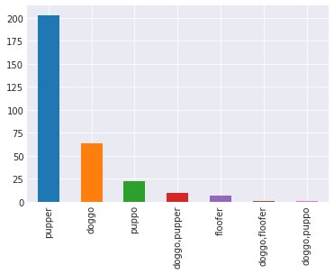

```python
df['dog_stage'].value_counts().plot(kind = 'bar')
```

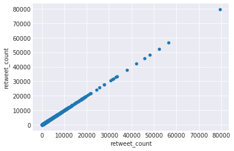

```python
df.plot(x = 'retweet_count', y = 'retweet_count', kind = 'scatter')
```

#### Question 3: What are the top 5 Dog breed by tweet

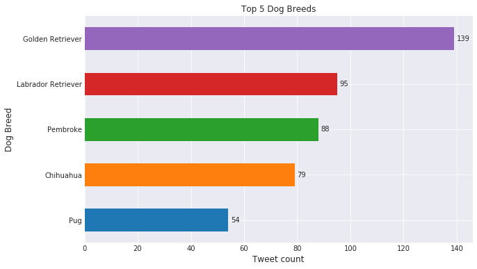

```python
plt.figure(figsize=(10,6))
df['dog_breed'].value_counts()[0:5].sort_values(ascending=True).plot(kind='barh')

# Set x label, ylabel and title:
plt.xlabel('Tweet count',size=12)
plt.ylabel('Dog Breed', size=12)
plt.title('Top 5 Dog Breeds' , size=12)

# Set x & y positions to add value over each bar:
x = df['dog_breed'].value_counts()[0:5].sort_values(ascending=True).values
y= np.arange(0,5,1)

# Add value over each bar:
for xx, yy in zip(x,y):
    plt.text(xx+1,yy,xx , va='center')
```

- Golden Retriever is the most common breed, it has the highest tweet of 139. followed by Labrador Retriever, pembroke, Chihuahua and pug with 95, 88, 79 and 54 tweets respectively.